# Prédiction spatiale : le krigeage

Marie-Pierre Etienne

marie-pierre.etienne@ensai.fr

ENSAI - CREST

https://marieetienne.github.io/statspat

2026-11-23

# Introduction

## Sources

Ce cours est construit principalement à partir de celui de Liliane Bel et des livres de Gaetan et al. (2010) et Cressie (2015).

## Champs aléatoires et processus

Un processus stochastique est une famille de variables aléatoires indexée par un ensemble $D$ :
$$\{Z(s), \; s \in D\}$$

- $D \subset {\mathbb{R}}$ (le temps) : on parle de **processus**,
- $D \subset {\mathbb{R}}^d$, $d \geq 2$ (l’espace) : on parle de **champ aléatoire**.

Une réalisation est

une fonction $s \mapsto z(s)$ sur tout $D$ : une carte.

La loi du champ est caractérisée par ses lois fini-dimensionnelles : celles de $(Z(s_1), \ldots, Z(s_n))$ pour tous $n$ et tous $s_1, \ldots, s_n$.

Champ gaussien : toutes ces lois sont gaussiennes, donc la loi est entièrement déterminée par la moyenne $\mu(s)$ et la covariance $c(s, s')$.

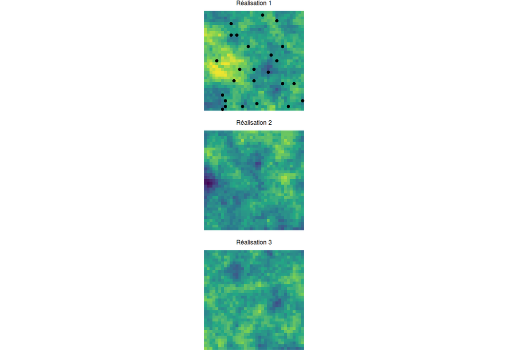

En statistique spatiale, on n’observe en général qu’une seule réalisation, et seulement en quelques sites (points noirs).

## Une question classique en statistique spatiale

On observe $z(s_1), \ldots, z(s_n)$ aux sites $s_1, \ldots, s_n$ d’un domaine $D$ et on veut :

- prédire $Z(s_0)$ en un site $s_0$ non observé,
- construire une carte de prédiction sur tout $D$,
- quantifier l’incertitude associée à cette carte.

### Exemples

- **La température en France**

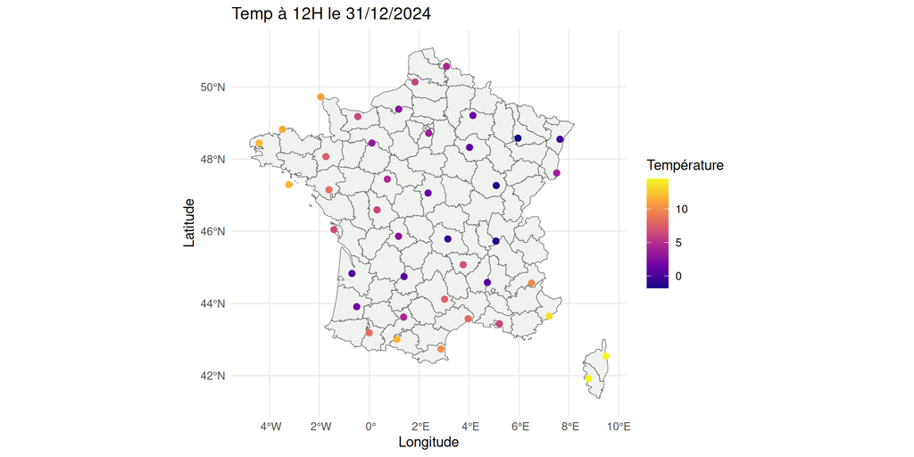

- **Pluies en Suisse** : $n = 100$ stations, on veut une carte de la pluie sur tout le territoire (voir le [TD](https://marieetienne.github.io/statspat/01_pluies.html#/title-slide)).

## Pourquoi ne pas simplement interpoler ?

Interpolateur par inverse de la distance :
$$\widehat{Z}(s_0) = \sum_{i=1}^n \lambda_i Z(s_i), \qquad \lambda_i \propto \frac{1}{\|s_0 - s_i\|^p}$$

### Limites

- Aucune mesure d’incertitude.
- Le poids d’un site ne dépend pas de la position des autres sites (deux sites collés comptent double).
- Les poids ne s’adaptent pas à la structure de dépendance des données (portée, régularité).

Le krigeage est une méthode d’interpolation qui choisit les poids à partir d’un **modèle de la dépendance spatiale**.

# Cadre : champ aléatoire du second ordre

## Champ aléatoire du second ordre

### Définition

Un champ aléatoire $\{Z(s), \; s \in D\}$, $D \subset {\mathbb{R}}^d$, est dit du second ordre si
$$\forall s \in D, \quad {\mathbb{E}}\left(Z(s)^2\right) < \infty.$$

On peut alors définir :

- sa fonction moyenne : $\mu(s) = {\mathbb{E}}(Z(s))$,
- sa fonction de covariance : $c(s, s') = {\mathbb{C}\text{ov}}(Z(s), Z(s'))$, (finie par Cauchy-Schwarz.)

### Propriétés de $c$

- $c(s, s) = {\mathbb{V}\text{ar}}(Z(s)) \geq 0$ et $c(s, s') = c(s', s)$,
- $|c(s, s')| \leq \sqrt{c(s, s)\, c(s', s')}$,
- $c$ est semi-définie positive : $\sum_{i,j} a_i a_j \, c(s_i, s_j) = {\mathbb{V}\text{ar}}\left(\sum_i a_i Z(s_i)\right) \geq 0$.

**Note**

Le second ordre ne suppose rien sur la loi. Un champ gaussien est du second ordre, et sa loi est entièrement déterminée par $\mu$ et $c$.

## Ce dont on a besoin pour prédire

On modélise $Z$ comme un champ aléatoire du second ordre :

- moyenne $\mu(s) = {\mathbb{E}}(Z(s))$,
- covariance $c(s, s') = {\mathbb{C}\text{ov}}(Z(s), Z(s'))$.

### Notations

- $\mathbf{Z} = (Z(s_1), \ldots, Z(s_n))^T$, $\widehat{Z}_0 = \widehat{Z}(s_0)$
- $\boldsymbol{\Sigma}$ : matrice $n\times n$, $\Sigma_{ij} = c(s_i, s_j)$
- $\boldsymbol{c_0}$ : vecteur de taille $n$, $c_{0,i} = c(s_0, s_i)$
- $\sigma_0^2 = {\mathbb{V}\text{ar}}(Z(s_0))$

Dans cette première partie du cours : on suppose la moyenne et la covariance **connues**. La question de leur estimation est repoussée à la fin.

## Covariance utilisée dans les illustrations

La covariance exponentielle est une forme de covariance classique dans les applications.

Elle décroît avec la distance entre les sites :
$$c(s, s') = \sigma^2 \exp\left(-\|s - s'\|/\rho\right) \; + \; \tau^2 \mathbb{1}_{s = s'}$$

- $\sigma^2$ : variance du signal,
- $\rho$ : vitesse de décroissance de la corrélation avec la distance (« portée »),
- $\tau^2$ : bruit de mesure (« pépite »).

On note $C(h) = \sigma^2 e^{-h/\rho}$ (+ $\tau^2$ si $h = 0$), de sorte que $c(s, s') = C(\|s - s'\|)$ : la covariance ne dépend que de la distance. Ce choix n’est pas anodin, on y reviendra.

```r
cov_exp <- function(h, sigma2 = 1, rho = 1) sigma2 * exp(-h / rho)
cov_gauss <- function(h, sigma2 = 1, rho = 1) sigma2 * exp(-(h / rho)^2)
```

# Krigeage simple : le cas gaussien

## Hypothèses

- $\mu$ **connue** et $C$ **connue**,
- $Z$ est un champ gaussien : tout vecteur $(Z(s_0), Z(s_1), \ldots, Z(s_n))$ est gaussien.

$$\begin{pmatrix} Z(s_0) \\ \mathbf{Z} \end{pmatrix} \sim
\mathcal{N}\left( \begin{pmatrix} \mu_0 \\ \boldsymbol{\mu} \end{pmatrix},
\begin{pmatrix} \sigma_0^2 & \boldsymbol{c_0}^T \\
\boldsymbol{c_0} & \boldsymbol{\Sigma} \end{pmatrix} \right)$$

### Question

Quelle est la loi de $Z(s_0)$ sachant $\mathbf{Z} = \mathbf{z}$ ?

## Conditionnement gaussien

$$Z(s_0) \mid \mathbf{Z} = \mathbf{z} \sim \mathcal{N}\left(
\mu_0 + \boldsymbol{c_0}^T \boldsymbol{\Sigma}^{-1} (\mathbf{z} - \boldsymbol{\mu}),
\; \sigma_0^2 - \boldsymbol{c_0}^T \boldsymbol{\Sigma}^{-1} \boldsymbol{c_0}
\right)$$

Prédicteur de krigeage simple
$$\widehat{Z}_{KS}(s_0) = {\mathbb{E}}(Z(s_0) \mid \mathbf{Z}) = \mu + \boldsymbol{c_0}^T \boldsymbol{\Sigma}^{-1} (\mathbf{Z} - \mu \mathbf{1})$$

Variance de krigeage
$$\sigma^2_{KS}(s_0) = {\mathbb{V}\text{ar}}(Z(s_0) \mid \mathbf{Z}) = \sigma_0^2 - \boldsymbol{c_0}^T \boldsymbol{\Sigma}^{-1} \boldsymbol{c_0}$$

### Interprétation

$$\widehat{Z}_{KS}(s_0) = \mu + \sum_{i=1}^n \lambda_i (Z(s_i) - \mu(s_i)), \qquad \boldsymbol{\lambda} = \boldsymbol{\Sigma}^{-1} \boldsymbol{c_0}$$

- On part de la moyenne $\mu$ et on la **corrige** en fonction des écarts observés à la moyenne.
- Les poids $\lambda_i$ dépendent de la covariance entre $s_0$ et les sites ($\boldsymbol{c_0}$) **et** de la redondance entre les sites ($\boldsymbol{\Sigma}^{-1}$).
- Les données font **baisser** la variance : $\sigma^2_{KS}(s_0) \le \sigma_0^2$.

Bonus du cadre gaussien : on a la loi prédictive complète, donc des intervalles de prédiction $\widehat{Z}_{KS}(s_0) \pm 1.96\, \sigma_{KS}(s_0)$, et toute quantité $P(Z(s_0) > \zeta \mid \mathbf{Z})$.

## Exercice 1 : une observation

On observe un seul site $s_1$. On suppose que la covariance entre 2 sites ne dépend que de leur distance. On note $c(s,s')=\tilde{c}(h)$, avec $h=\|s - s'\|$

1. Que représente $c(0)$ dans ce cas ?

On note $r = c(\|s_0 - s_1\|) / c(0)$

2. Que représente $r$ ?
3. Donner $\widehat{Z}_{KS}(s_0)$ et $\sigma^2_{KS}(s_0)$.
4. Que se passe-t-il quand $s_0 \to s_1$ ? Quand $\|s_0 - s_1\| \to \infty$ ?

## Exercice 2: deux observations

On se place en 1D : $s_0 = 0$, $s_1 = 1$, $s_2 = 2$, $\mu(s) = 0$.

Calculer les poids $\lambda_1, \lambda_2$ pour

1. une covariance exponentielle :
   $$c(s, s') = \sigma^2 \exp\left(-\|s - s'\|/\rho\right)$$
2. une covariance gaussienne.:
   $$c(s, s') = \sigma^2 \exp\left(-\|s - s'\|^2/\rho^2\right)$$

```r
poids_ks <- function(s0, s, covf, ...) {
  Sigma <- covf(as.matrix(dist(s)), ...)
  c0 <- covf(abs(s - s0), ...)
  solve(Sigma, c0)
}
round(poids_ks(0, c(1, 2), cov_exp, rho = 1), 3)
```

```
    1     2
0.368 0.000
```

```r
round(poids_ks(0, c(1, 2), cov_gauss, rho = 1), 3)
```

```
     1      2
 0.418 -0.135
```

## Effet d’écran et poids négatifs

- Effet d’écran : le site $s_1$ « masque » $s_2$. En 1D avec une covariance exponentielle, $\lambda_2 = 0$ exactement (propriété de Markov du processus d’Ornstein-Uhlenbeck).
- Poids négatifs : avec une covariance très régulière (gaussienne), le poids de $s_2$ est négatif. Le krigeage **extrapole** la tendance locale.

**Note**

Contrairement à l’inverse de la distance, on n’a pas forcément $0 \le \lambda_i \le 1$ : le prédicteur peut sortir de l’intervalle des valeurs observées.

# Krigeage simple sans hypothèse gaussienne

## Le meilleur prédicteur linéaire (BLUP)

On ne suppose plus que $Z$ est gaussien. Seuls les deux premiers moments sont connus.

On cherche un prédicteur **linéaire** $\widehat{Z}(s_0) = \alpha + \boldsymbol{\lambda}^T \mathbf{Z}$ qui minimise le risque quadratique
$$R(\alpha, \boldsymbol{\lambda}) = {\mathbb{E}}\left[ (Z(s_0) - \alpha - \boldsymbol{\lambda}^T \mathbf{Z})^2 \right].$$

### Exercice

1. Montrer que $R(\alpha, \boldsymbol{\lambda}) = (\mu - \alpha - \mu \boldsymbol{\lambda}^T \mathbf{1})^2 + \sigma_0^2 - 2 \boldsymbol{\lambda}^T \boldsymbol{c_0} + \boldsymbol{\lambda}^T \boldsymbol{\Sigma} \boldsymbol{\lambda}$.
2. En déduire $\alpha$ et $\boldsymbol{\lambda}$ optimaux.

## Solution

$$\boldsymbol{\lambda} = \boldsymbol{\Sigma}^{-1} \boldsymbol{c_0}, \qquad \alpha = \mu (1 - \boldsymbol{\lambda}^T \mathbf{1})$$

On retrouve exactement le même prédicteur et la même variance d’erreur :
$$\widehat{Z}_{KS}(s_0) = \mu + \boldsymbol{c_0}^T \boldsymbol{\Sigma}^{-1} (\mathbf{Z} - \mu \mathbf{1}), \qquad {\mathbb{E}}\left[(Z(s_0) - \widehat{Z}_{KS}(s_0))^2\right] = \sigma_0^2 - \boldsymbol{c_0}^T \boldsymbol{\Sigma}^{-1} \boldsymbol{c_0}$$

## Gaussien ou pas : ce qui change

|  | Cas gaussien | Second ordre seulement |
| --- | --- | --- |
| Prédicteur | $\widehat{Z}_{KS}(s_0)$ | $\widehat{Z}_{KS}(s_0)$ |
| Optimal parmi | **tous** les prédicteurs | les prédicteurs **linéaires** |
| $\sigma^2_{KS}(s_0)$ est | la variance conditionnelle | l’erreur quadratique moyenne |
| Intervalle $\pm 1.96\,\sigma_{KS}$ | exact | approximatif |
| $P(Z(s_0) > \zeta \mid \mathbf{Z})$ | disponible | non disponible |

À retenir : l’hypothèse gaussienne ne change pas la formule, elle change ce qu’on peut **en dire**.

# Propriétés du krigeage

## Une illustration en 1D

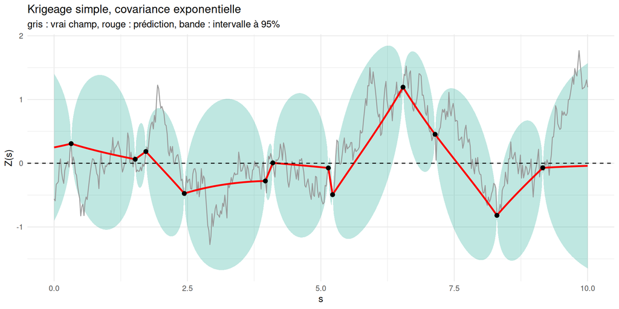

## Interpolation exacte et effet pépite

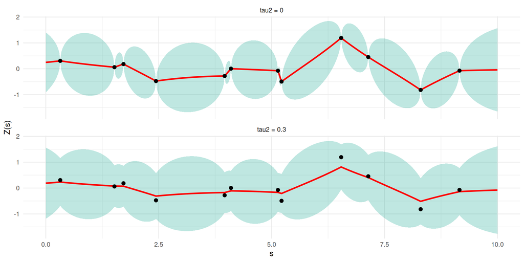

- Sans pépite : $\widehat{Z}(s_i) = Z(s_i)$ et $\sigma^2_{KS}(s_i) = 0$, le krigeage est un interpolateur exact.
- Avec pépite : le krigeage **lisse**, on ne fait plus confiance à 100% aux observations.

## Effet de la portée

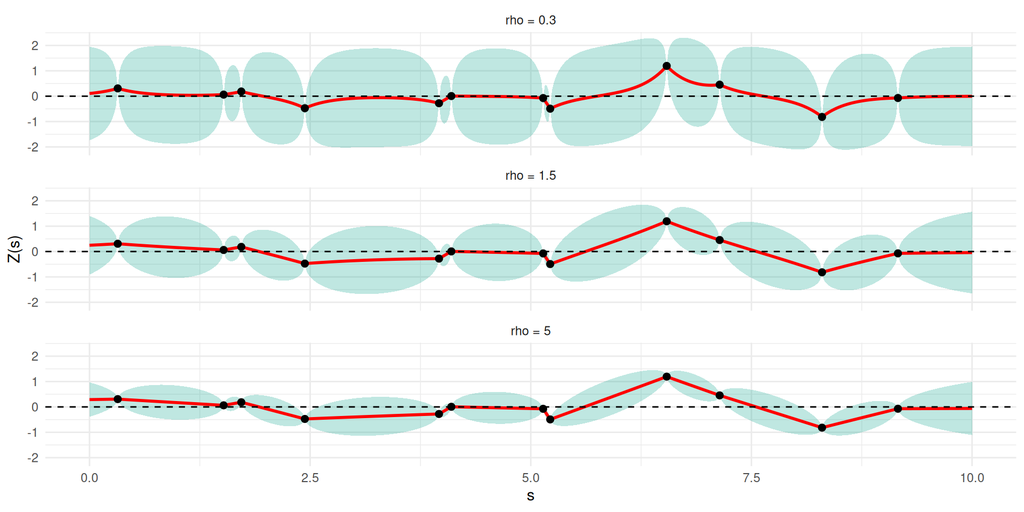

Loin des données (à l’échelle de la portée) : $\widehat{Z}(s_0) \to \mu$ et $\sigma^2_{KS}(s_0) \to C(0)$.

## La variance de krigeage ne dépend pas des valeurs observées

$$\sigma^2_{KS}(s_0) = \sigma_0^2 - \boldsymbol{c_0}^T \boldsymbol{\Sigma}^{-1} \boldsymbol{c_0}$$

ne dépend que :

- de la **position** des sites $s_1, \ldots, s_n$ et de $s_0$,
- du **modèle** de covariance.

### Conséquences

- On peut calculer la carte d’incertitude avant de collecter les données : c’est un outil de **plan d’échantillonnage** (où placer une nouvelle station ?).
- L’incertitude ne réagit pas à des valeurs surprenantes, si le modèle est faux.

# Krigeage ordinaire

## Moyenne inconnue

On suppose maintenant $\mu$ inconnue (constante), $C$ connue.

On cherche $\widehat{Z}(s_0) = \boldsymbol{\lambda}^T \mathbf{Z}$ :

- **sans biais** pour tout $\mu$ : ${\mathbb{E}}(\widehat{Z}(s_0)) = \mu$ $\Leftrightarrow$ $\boldsymbol{\lambda}^T \mathbf{1}= 1$,
- de **variance d’erreur minimale** : $\min \; \sigma_0^2 - 2 \boldsymbol{\lambda}^T \boldsymbol{c_0} + \boldsymbol{\lambda}^T \boldsymbol{\Sigma} \boldsymbol{\lambda}$.

### Exercice

Résoudre ce problème par la méthode du multiplicateur de Lagrange.

## Solution

$$\boldsymbol{\lambda}_{KO} = \boldsymbol{\Sigma}^{-1} (\boldsymbol{c_0} + m \mathbf{1}), \qquad m = \frac{1 - \mathbf{1}^T \boldsymbol{\Sigma}^{-1} \boldsymbol{c_0}}{\mathbf{1}^T \boldsymbol{\Sigma}^{-1} \mathbf{1}}$$

### Relecture

Avec $\widehat{\mu} = \dfrac{\mathbf{1}^T \boldsymbol{\Sigma}^{-1} \mathbf{Z}}{\mathbf{1}^T \boldsymbol{\Sigma}^{-1} \mathbf{1}}$ l’estimateur des moindres carrés généralisés de $\mu$ (c’est aussi le meilleur estimateur linéaire sans biais, BLUE) :
$$\widehat{Z}_{KO}(s_0) = \widehat{\mu} + \boldsymbol{c_0}^T \boldsymbol{\Sigma}^{-1} (\mathbf{Z} - \widehat{\mu} \mathbf{1})$$

Krigeage ordinaire = krigeage simple dans lequel on remplace $\mu$ par son estimateur BLUE.

## Variance de krigeage ordinaire

$$\sigma^2_{KO}(s_0) = \underbrace{\sigma_0^2 - \boldsymbol{c_0}^T \boldsymbol{\Sigma}^{-1} \boldsymbol{c_0}}_{\sigma^2_{KS}(s_0)} + \underbrace{\frac{(1 - \mathbf{1}^T \boldsymbol{\Sigma}^{-1} \boldsymbol{c_0})^2}{\mathbf{1}^T \boldsymbol{\Sigma}^{-1} \mathbf{1}}}_{\text{coût de l'estimation de } \mu}$$

- $\sigma^2_{KO}(s_0) \ge \sigma^2_{KS}(s_0)$.
- Près des données, $\mathbf{1}^T \boldsymbol{\Sigma}^{-1} \boldsymbol{c_0}$ est proche de 1 et le surcoût est faible.
- Loin des données, on prédit $\widehat{\mu}$ et on paye ${\mathbb{V}\text{ar}}(\widehat{\mu}) = 1 / (\mathbf{1}^T \boldsymbol{\Sigma}^{-1} \mathbf{1})$.

## Simple vs ordinaire

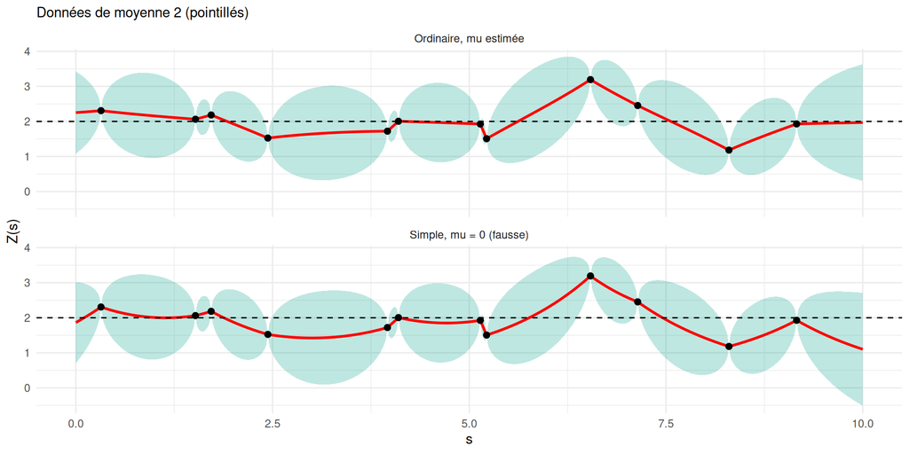

## Estimer la moyenne : une tâche ingrate

Le second terme de $\sigma^2_{KO}$ fait apparaître ${\mathbb{V}\text{ar}}(\widehat{\mu}) = 1 / (\mathbf{1}^T \boldsymbol{\Sigma}^{-1} \mathbf{1})$.

Que se passe-t-il quand on ajoute des stations **dans le même domaine** ?

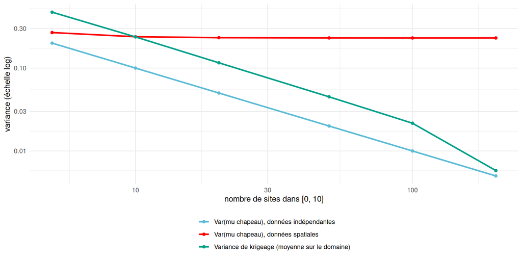

- Densifier les observations n’apprend presque rien de plus sur $\mu$ : des données corrélées n’apportent pas $n$ informations indépendantes (taille d’échantillon effective).
- En revanche, la prédiction devient de plus en plus précise.

La dépendance spatiale est un handicap pour estimer la moyenne et un atout pour prédire.

# Krigeage universel

## Une moyenne qui dépend de covariables

On suppose maintenant
$$Z(s) = X(s)^T \beta + \varepsilon(s), \qquad {\mathbb{E}}(\varepsilon(s)) = 0, \quad {\mathbb{C}\text{ov}}(\varepsilon(s), \varepsilon(s')) = c(s, s') \text{ connue},$$
avec $X(s) \in {\mathbb{R}}^p$ connu en **tout** site (y compris $s_0$) et $\beta$ inconnu.

- Covariables : altitude, distance à la rivière… (« dérive externe »)
- Coordonnées : $X(s) = (1, x, y)$ pour une tendance spatiale (« dérive interne »)

### Notations

$\mathbf{X}$ : matrice $n \times p$ des covariables aux sites observés, $X_0 = X(s_0)$.

## Le problème d’optimisation

On cherche $\widehat{Z}(s_0) = \boldsymbol{\lambda}^T \mathbf{Z}$ :

- **sans biais pour tout** $\beta$ : $\boldsymbol{\lambda}^T \mathbf{X} \beta = X_0^T \beta \; \forall \beta \Leftrightarrow \mathbf{X}^T \boldsymbol{\lambda} = X_0$ ($p$ contraintes),
- de **variance d’erreur minimale** : $\min \; \sigma_0^2 - 2 \boldsymbol{\lambda}^T \boldsymbol{c_0} + \boldsymbol{\lambda}^T \boldsymbol{\Sigma} \boldsymbol{\lambda}$.

### Exercice

1. Écrire le lagrangien avec un vecteur de multiplicateurs $\mathbf{m} \in {\mathbb{R}}^p$.
2. Montrer que $\boldsymbol{\lambda} = \boldsymbol{\Sigma}^{-1}(\boldsymbol{c_0} + \mathbf{X}\mathbf{m})$ et déterminer $\mathbf{m}$.
3. Vérifier que le krigeage ordinaire est le cas $X(s) = 1$.

## Solution

$$\mathbf{m} = (\mathbf{X}^T \boldsymbol{\Sigma}^{-1} \mathbf{X})^{-1} (X_0 - \mathbf{X}^T \boldsymbol{\Sigma}^{-1} \boldsymbol{c_0})$$

### Relecture

Avec $\widehat{\beta} = (\mathbf{X}^T \boldsymbol{\Sigma}^{-1} \mathbf{X})^{-1} \mathbf{X}^T \boldsymbol{\Sigma}^{-1} \mathbf{Z}$ l’estimateur des moindres carrés généralisés :
$$\widehat{Z}_{KU}(s_0) = \underbrace{X_0^T \widehat{\beta}}_{\text{tendance}} + \underbrace{\boldsymbol{c_0}^T \boldsymbol{\Sigma}^{-1} (\mathbf{Z} - \mathbf{X} \widehat{\beta})}_{\text{krigeage simple des résidus}}$$

$$\sigma^2_{KU}(s_0) = \sigma^2_{KS}(s_0) + \underbrace{\left( X_0 - \mathbf{X}^T \boldsymbol{\Sigma}^{-1} \boldsymbol{c_0} \right)^T \left( \mathbf{X}^T \boldsymbol{\Sigma}^{-1} \mathbf{X} \right)^{-1} \left( X_0 - \mathbf{X}^T \boldsymbol{\Sigma}^{-1} \boldsymbol{c_0} \right)}_{\text{coût de l'estimation de } \beta}$$

## Illustration : tendance linéaire en 1D

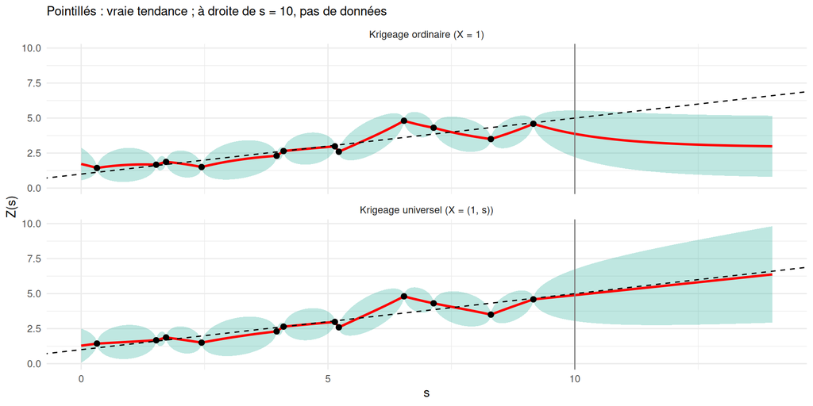

Loin des données, le krigeage universel **suit la tendance**, avec une incertitude croissante (extrapolation de $\widehat\beta$).

## Remarques

- Les covariables doivent être connues **partout** où l’on prédit (sur toute la grille).
- Cercle vicieux : pour estimer $\beta$ par moindres carrés généralisés, il faut la covariance des résidus ; pour estimer la covariance des résidus, il faut $\beta$.
  - en pratique : $\widehat\beta$ par moindres carrés ordinaires, variogramme des résidus, puis krigeage universel (ce que fait `gstat`),
  - ou estimation conjointe par maximum de vraisemblance (restreint, REML).
- Séparer tendance et dépendance est en partie un **choix de modélisation** : une tendance mal spécifiée se retrouve dans le variogramme.

# D’où vient la covariance ?

## La question qui reste

En pratique, ni $\mu$ ni la covariance ne sont connues.

- Il faudrait connaître $c(s_i, s_j)$ pour **chaque paire** de sites, et $c(s_0, s_i)$ pour un site **jamais observé**.
- Or on n’a souvent qu’une seule réalisation du champ : un seul couple $(Z(s_i), Z(s_j))$ par paire de sites.

### Discussion

- Peut-on estimer ${\mathbb{C}\text{ov}}(Z(s_i), Z(s_j))$ à partir d’une seule observation de $(Z(s_i), Z(s_j))$ ?
- Quelle hypothèse permettrait de « mutualiser » l’information entre paires de sites ?

## Toute fonction ne peut pas être une covariance

$Z$ est un processus du second ordre si $\forall s \in D, \; {\mathbb{E}}(Z(s)^2) < \infty$, de moyenne $m(s) = {\mathbb{E}}(Z(s))$ et de covariance $c(s, t) = {\mathbb{C}\text{ov}}(Z(s), Z(t))$.

**Propriété Une fonction de covariance est semi-définie positive**

$$\forall n, \; \forall s_1, \ldots, s_n \in D, \; \forall a \in {\mathbb{R}}^n, \quad \sum_{i,j=1}^n a_i a_j \, c(s_i, s_j) \geq 0$$

*Idée de preuve* : regarder ${\mathbb{V}\text{ar}}\left(\sum_{i=1}^n a_i Z(s_i)\right)$.

**Note**

C’est ce qui garantit que les variances de krigeage sont positives et que $\boldsymbol{\Sigma}$ est inversible (si définie positive). On ne peut donc pas choisir n’importe quelle fonction : on travaille avec des **familles de covariances valides**.

## Stationnarité du second ordre

### Définition

Un processus du second ordre $Z$ est stationnaire sur $D \subset {\mathbb{R}}^d$ si

1. sa moyenne est constante : $\forall s \in D, \; m(s) = \mu$,
2. sa covariance est invariante par translation :
   $$\forall s, s + h \in D, \quad c(s, s + h) = C(h).$$

### Isotropie

Le processus est isotrope si $C(h)$ ne dépend que de $\|h\|$ : $C(h) = C(\|h\|)$.

Conséquence : toutes les paires de sites séparées par $h$ renseignent sur la même quantité $C(h)$. C’est le choix fait dans les illustrations précédentes.

## Stationnarité des accroissements

$Z$ est à accroissements stationnaires (ou intrinsèque) si
$${\mathbb{E}}(Z(s + h) - Z(s)) = 0, \qquad {\mathbb{V}\text{ar}}(Z(s + h) - Z(s)) = 2\gamma(h).$$

- La stationnarité du second ordre implique la stationnarité des accroissements.
- La classe des processus intrinsèques est donc plus **large** que celle des processus stationnaires.

### Exemple

Que dire du mouvement brownien sur ${\mathbb{R}}$ ?

${\mathbb{V}\text{ar}}(B(t)) = t$ : il n’est pas stationnaire. Mais ${\mathbb{V}\text{ar}}(B(t + h) - B(t)) = |h|$ : il est intrinsèque, avec $\gamma(h) = |h| / 2$.

# Le variogramme

## Définition

Le semi-variogramme d’un processus intrinsèque est
$$\gamma(h) = \frac{1}{2} {\mathbb{V}\text{ar}}(Z(s + h) - Z(s)) = \frac{1}{2} {\mathbb{E}}\left[(Z(s + h) - Z(s))^2\right].$$

### Propriétés

- $\gamma(h) \geq 0$, $\gamma(0) = 0$, $\gamma(-h) = \gamma(h)$.
- Si $Z$ est stationnaire du second ordre :
  $$\gamma(h) = C(0) - C(h).$$
- Un variogramme **borné** correspond (à une constante aléatoire près) à un processus stationnaire du second ordre, et sa limite vaut $C(0)$.

**Pourquoi le variogramme ? Il ne fait pas intervenir la moyenne**

on peut l’estimer sans estimer $\mu$.

## Modèles classiques de variogramme

1. **Pépitique** : $\gamma(h) = C \, \mathbb{1}_{h \neq 0}$
2. **Exponentiel** : $\gamma(h) = C(1 - \exp(-\|h\|/\rho))$
3. **Sphérique** :
   $$\gamma(h) = \begin{cases}
   C \left( \frac{3}{2} \frac{\|h\|}{\rho} - \frac{1}{2} \left(\frac{\|h\|}{\rho}\right)^3 \right) & \text{si } \|h\| \leq \rho \\
   C & \text{si } \|h\| > \rho
   \end{cases}$$
4. **Gaussien** : $\gamma(h) = C(1 - \exp(-\|h\|^2/\rho^2))$
5. **Puissance** : $\gamma(h) = C \|h\|^\alpha$, $0 < \alpha < 2$ (non borné : processus intrinsèque non stationnaire)

## La famille de Matérn

$$C(h) = \sigma^2 \frac{2^{1 - \nu}}{\Gamma(\nu)} \left(\frac{\sqrt{2\nu}\, \|h\|}{\rho}\right)^{\nu} K_{\nu}\left(\frac{\sqrt{2\nu}\, \|h\|}{\rho}\right), \qquad \gamma(h) = \sigma^2 - C(h)$$

$K_{\nu}$ : fonction de Bessel modifiée de seconde espèce, d’ordre $\nu$.

$\nu$ règle la régularité du processus (comportement du variogramme en 0) :

- $\nu = 1/2$ : modèle exponentiel (trajectoires continues, non dérivables),
- $\nu \to \infty$ : modèle gaussien (trajectoires infiniment dérivables).

C’est la famille utilisée par défaut dans INLA (approche SPDE).

## Paramètres du variogramme

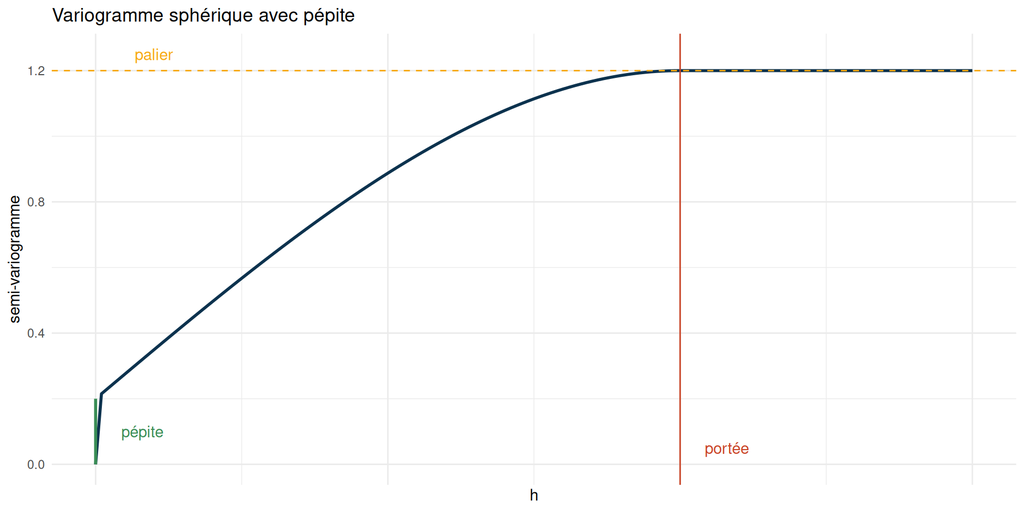

## Interprétation des paramètres

- Palier $\lim_{h \to \infty} \gamma(h)$ : s’il est fini, le processus est stationnaire et le palier vaut ${\mathbb{V}\text{ar}}(Z(s))$.
- Échelle $\rho$ : vitesse à laquelle le variogramme rejoint le palier.
- Portée : distance au-delà de laquelle la corrélation est nulle ou négligeable (horizon de dépendance).
- Pépite $\tau^2 = \lim_{h \to 0^+} \gamma(h)$ :
  - si $\tau^2 \neq 0$, variabilité à très petite échelle ou erreur de mesure (le krigeage lisse),
  - si $\tau^2 = 0$, la régularité du processus est donnée par le comportement de $\gamma$ en 0 (paramètre $\nu$ de Matérn).

## Krigeage et variogramme

Sous stationnarité, on remplace $C(h) = C(0) - \gamma(h)$ dans les formules.

Remarque : le krigeage ordinaire (contrainte $\boldsymbol{\lambda}^T \mathbf{1}= 1$) peut s’écrire **uniquement** avec $\gamma$. Il reste donc valable pour des processus intrinsèques non stationnaires. C’est la présentation historique de Matheron.

# Estimation du variogramme

## Exemple : les données Meuse

Concentrations en zinc (ppm) dans les sols de la plaine inondable de la Meuse, 155 sites (package `sp`).

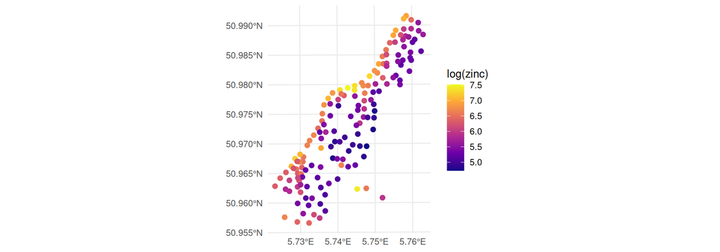

```r
library(sf)
library(gstat)
data(meuse, package = "sp")
meuse_sf <- st_as_sf(meuse, coords = c("x", "y"), crs = 28992)
ggplot(meuse_sf) + geom_sf(aes(col = log(zinc)), size = 2) +
  scale_color_viridis_c(option = "plasma")
```

## Nuée variographique

$$\gamma(h) = \frac{1}{2} {\mathbb{E}}\left[(Z(s + h) - Z(s))^2\right]$$

Pour chaque paire $(i, j)$, on représente $\frac{1}{2}(Z(s_i) - Z(s_j))^2$ en fonction de $\|s_i - s_j\|$.

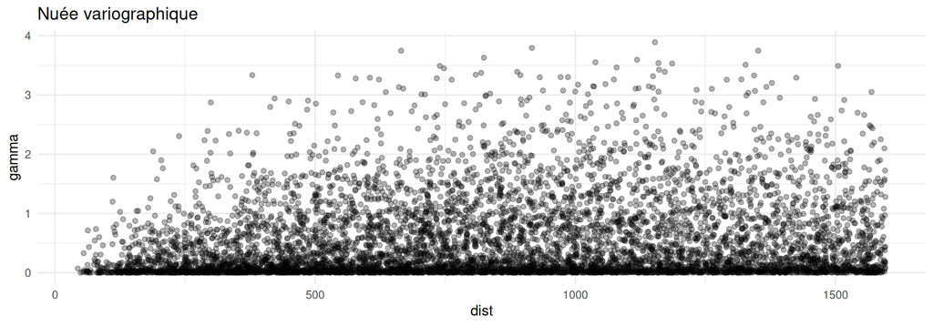

```r
vario.cloud <- variogram(log(zinc) ~ 1, data = meuse_sf, cloud = TRUE)
ggplot(vario.cloud, aes(x = dist, y = gamma)) + geom_point(alpha = 0.3) +
  ggtitle("Nuée variographique")
```

## Variogramme empirique

On regroupe les paires par classes de distance $d_k$ (de largeur $\delta$), avec $N(k)$ l’ensemble des $n_k$ paires de la classe $k$ :
$$\widetilde \gamma (d_k) = \frac{1}{2 n_k} \sum_{(i, j) \in N(k)} (Z(s_i) - Z(s_j))^2$$

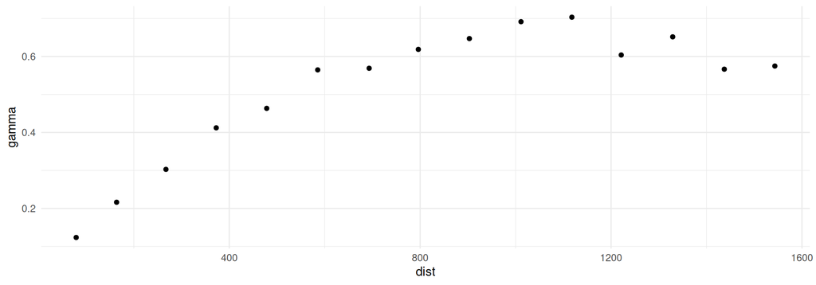

```r
vario.b <- variogram(log(zinc) ~ 1, data = meuse_sf)
ggplot(vario.b, aes(x = dist, y = gamma)) + geom_point()
```

L’option `alpha = c(0, 45, 90, 135)` donne des variogrammes **directionnels**, pour vérifier l’isotropie.

## Propriétés du variogramme empirique

- Approximativement sans biais (à la largeur des classes près).
- Ne nécessite pas d’estimer la moyenne (si elle est constante).
- Si $Z$ est gaussien, chaque terme est un $\gamma(h)\chi^2(1)$ : estimateur très **sensible aux valeurs extrêmes**.
- Peu fiable aux grandes distances (peu de paires) : on se limite généralement à la moitié de la distance maximale.

### Estimateur robuste (Cressie-Hawkins)

$$\widetilde \gamma (d_k) = \frac{\left\{\frac{1}{n_k} \sum_{(i, j) \in N(k)} |Z(s_i) - Z(s_j)|^{1/2}\right\}^4}{2\left(0.457 + \frac{0.494}{n_k}\right)}$$

## Ajustement d’un modèle de variogramme

Le variogramme empirique n’est pas un variogramme valide : on ajuste un modèle paramétrique $\gamma_\theta$, avec $\theta = (\sigma^2, \rho, \nu, \tau^2)$.

Moindres carrés pondérés
$$\widehat\theta = \arg\min_{\theta} \sum_{k=1}^K w_k \left(\gamma_\theta(d_k) - \widetilde \gamma(d_k)\right)^2, \qquad w_k = \frac{n_k}{\gamma_\theta(d_k)^2} \text{ (Cressie)}$$

```r
v.fit <- fit.variogram(vario.b, vgm(model = "Sph", psill = 0.6, range = 900, nugget = 0.05))
v.fit
```

```
  model      psill    range
1   Nug 0.05066522   0.0000
2   Sph 0.59061054 897.0412
```

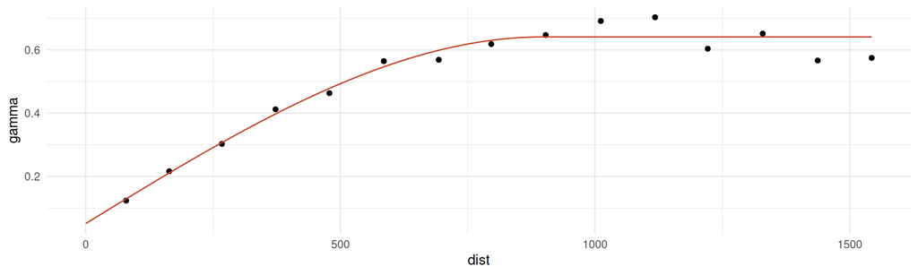

```r
ggplot(vario.b, aes(x = dist, y = gamma)) + geom_point() +
  geom_line(data = variogramLine(v.fit, maxdist = max(vario.b$dist)), col = "#C94326")
```

Alternative : maximum de vraisemblance sous hypothèse gaussienne, qui utilise directement les données et non le variogramme empirique.

# Le krigeage en pratique

## Démarche

1. Explorer les données, modéliser la **tendance** (moyenne) éventuelle.
2. Calculer le variogramme empirique (des résidus), vérifier l’isotropie.
3. Ajuster un modèle de variogramme.
4. Kriger sur une grille : carte de prédiction **et** carte de variance.
5. Valider (validation croisée : `krige.cv`).
6. Si besoin, simuler conditionnellement pour des quantités non linéaires.

```r
data(meuse.grid, package = "sp")
grille <- st_as_sf(meuse.grid, coords = c("x", "y"), crs = 28992)
K <- krige(log(zinc) ~ 1, locations = meuse_sf, newdata = grille, model = v.fit)
```

```
[using ordinary kriging]
```

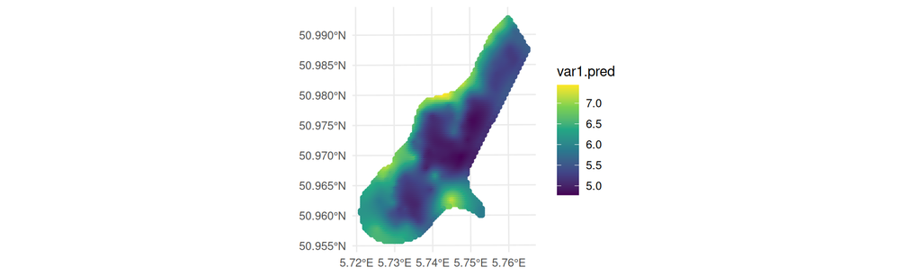

```r
ggplot(K) + geom_sf(aes(col = var1.pred)) + scale_color_viridis_c()
```

## Krigeage universel avec `gstat`

Le zinc décroît avec la distance à la Meuse : on l’utilise comme covariable (connue sur toute la grille `meuse.grid`).

```r
vario.res <- variogram(log(zinc) ~ sqrt(dist), data = meuse_sf)   # variogramme des résidus
v.fit.res <- fit.variogram(vario.res, vgm(model = "Sph", psill = 0.2, range = 800, nugget = 0.05))
KU <- krige(log(zinc) ~ sqrt(dist), locations = meuse_sf, newdata = grille, model = v.fit.res)
```

```
[using universal kriging]
```

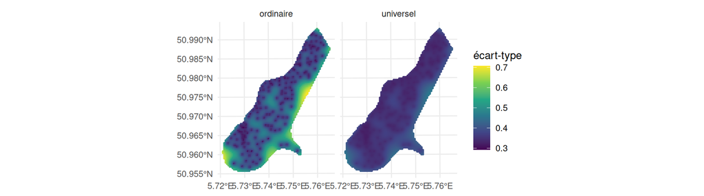

```r
bind_rows(K |> mutate(methode = "ordinaire"), KU |> mutate(methode = "universel")) |>
  ggplot() + geom_sf(aes(col = sqrt(var1.var)), size = 0.5) + facet_wrap(~methode) +
  scale_color_viridis_c(name = "écart-type")
```

La covariable explique une partie de la variabilité : le palier des résidus est plus faible et l’incertitude diminue.

# Simulation conditionnelle

## Pourquoi simuler ?

La carte de krigeage est plus lisse que la réalité : ${\mathbb{V}\text{ar}}(\widehat{Z}(s_0)) = \sigma_0^2 - \sigma^2_K(s_0) < \sigma_0^2$.

Elle donne la meilleure prédiction **site par site**, mais elle est mauvaise pour des quantités qui dépendent du champ **dans son ensemble** :

- surface du domaine où la concentration dépasse un seuil,
- maximum du champ sur une région,
- longueur d’un front, connectivité de zones polluées…

Pour une fonctionnelle non linéaire $\varphi$ : $\varphi(\widehat{Z}) \neq {\mathbb{E}}(\varphi(Z) \mid \mathbf{Z})$.

Idée : tirer des réalisations du champ **sachant les observations** et calculer $\varphi$ sur chacune.

## Loi conditionnelle dans le cas gaussien

On veut simuler $\mathbf{Z}_G = (Z(g_1), \ldots, Z(g_N))$ sur une grille, sachant $\mathbf{Z}$. Comme pour le krigeage simple :

$$\mathbf{Z}_G \mid \mathbf{Z} \sim \mathcal{N}\left( \mu \mathbf{1}+ \mathbf{C}_{G}^T \boldsymbol{\Sigma}^{-1} (\mathbf{Z} - \mu \mathbf{1}), \; \boldsymbol{\Sigma}_{GG} - \mathbf{C}_{G}^T \boldsymbol{\Sigma}^{-1} \mathbf{C}_{G} \right)$$

avec $\mathbf{C}_G$ la matrice $n \times N$ des covariances entre sites observés et points de grille.

- Moyenne : la carte de krigeage.
- Covariance : la covariance des erreurs de krigeage (sa diagonale est la variance de krigeage).

### Simulation directe

$\mathbf{Z}_G = \widehat{Z}_G + \mathbf{L}\,\mathbf{U}$, avec $\mathbf{L}\mathbf{L}^T$ la covariance conditionnelle (Cholesky) et $\mathbf{U} \sim \mathcal{N}(0, I_N)$. Coût en $O(N^3)$ : impossible sur une grande grille.

## Conditionnement par krigeage

Propriété clé du cas gaussien : l’erreur de krigeage $Z(s) - \widehat{Z}(s)$ est **indépendante** des données (non corrélée et gaussienne).

### Algorithme

1. Simuler une réalisation **non conditionnelle** $Z_s$ sur la grille et aux sites observés.
2. Kriger à partir des valeurs simulées $Z_s(s_1), \ldots, Z_s(s_n)$ : on obtient $\widehat{Z}_s$.
3. Poser
   $$Z_{cs} = \underbrace{\widehat{Z}}_{\text{krigeage des vraies données}} + \underbrace{(Z_s - \widehat{Z}_s)}_{\text{erreur de krigeage simulée}}$$

### Exercice

Montrer que $Z_{cs}$ a la bonne loi conditionnelle et qu’elle interpole les données (sans pépite).

## Illustration en 1D

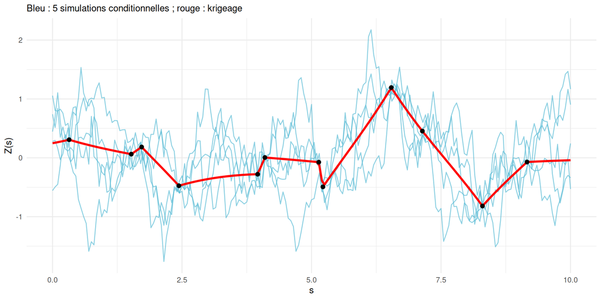

Les simulations passent par les données et ont la **même rugosité** que le vrai champ, contrairement au krigeage.

## Exemple : proportion du domaine au-dessus d’un seuil

On cherche la proportion de $[0, 10]$ où $Z(s) > 0.5$.

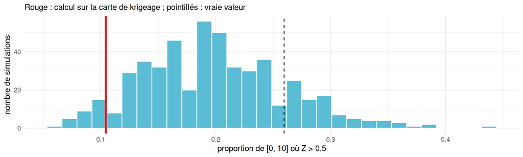

- Les 500 simulations donnent la loi conditionnelle de la proportion : estimation **et** incertitude.
- Le calcul sur la carte de krigeage, trop lisse, est biaisé.

## En pratique avec `gstat`

`krige(..., nsim = )` utilise la simulation séquentielle gaussienne : on parcourt la grille dans un ordre aléatoire et on simule chaque point selon sa loi conditionnelle sachant les données et les points déjà simulés (dans un voisinage `nmax`).

```r
set.seed(1)
sim_meuse <- krige(log(zinc) ~ sqrt(dist), locations = meuse_sf, newdata = grille,
                   model = v.fit.res, nsim = 4, nmax = 30)
```

```
drawing 4 GLS realisations of beta...
[using conditional Gaussian simulation]
```

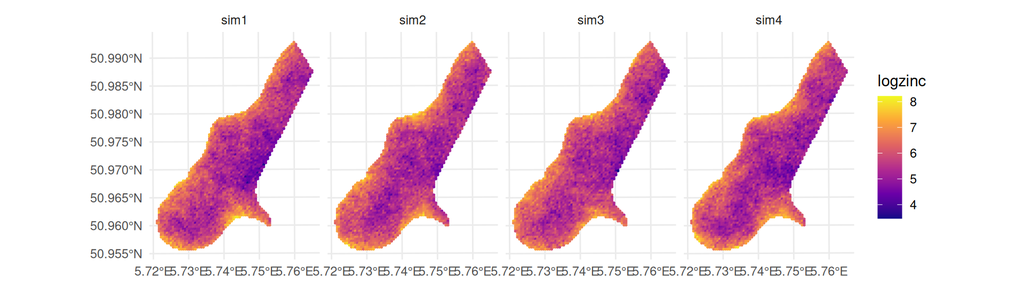

```r
sim_meuse |> pivot_longer(starts_with("sim"), names_to = "sim", values_to = "logzinc") |>
  st_as_sf() |> ggplot() + geom_sf(aes(col = logzinc), size = 0.3) + facet_wrap(~sim, nrow = 1) +
  scale_color_viridis_c(option = "plasma")
```

**Note**

**Les simulations permettent de revenir à l’échelle d’origine sans biais**

$\exp$ des simulations de $\log(\text{zinc})$, alors que $\exp(\widehat{Z})$ n’est pas le prédicteur optimal du zinc.

# Conclusion

## Limites

### Le plug-in

On estime la covariance, puis on l’injecte dans les formules comme si elle était connue.

**Note**

La variance de krigeage plug-in ne tient pas compte de l’incertitude sur $\widehat{C}$ : elle sous-estime l’incertitude réelle. L’approche bayésienne (INLA) permet de propager cette incertitude.

### Et si les données ne sont pas gaussiennes ?

- Le BLUP reste valable, mais sans intervalles exacts.
- Souvent préférable : transformer (log, Box-Cox) ou utiliser un modèle hiérarchique (GLM spatial, voir INLA).

## En pratique

Voir le [TP](https://marieetienne.github.io/statspat/01_pluies.html#/title-slide) sur les pluies en Suisse.

## Références

Cressie, Noel. 2015. *Statistics for Spatial Data*. John Wiley & Sons.

Gaetan, Carlo, Xavier Guyon, et al. 2010. *Spatial Statistics and Modeling*. Vol. 90. Springer.